# Eksperymenty z wykresami

Pola Mościcka, Aleksandra Kornel, Maciej Wach

2023-03-26

# Eksperyment I - odpowiedni dobór kolorów

#### Wygenerowaliśmy 3 wykresy, które miały niepoprawnie dobraną szatę graficzną. Następnie stworzyliśmy ankietę w Google Forms i rozesłaliśmy ją do 21 osób w wieku 20-22 lata. Do każdego z wykresów dobraliśmy po 2 proste pytania dotyczące jego treści, na które ankietowani mieli odpowiedzieć po wcześniejszym zapoznaniu się z wykresem. Na początku ankiety była umieszczona informacja, aby nie spędzać dłużej niż 15 sekund przy każdym pytaniu czy podczas zapoznawiania się z wykresem. Miało to na celu sprawdzenie bardziej intuicyjnych odpowiedzi, które narzucają się na pierwszy rzut oka. W dzisiejszych czasach to zwykle tak analizujemy otaczające nas informacje i wykresy, czy to w telewizji, czy to na banerach reklamowych.

##### Dane użyte do stworzenia wykresów pochodzą z ramki danych SmarterPoland.

## Wykres 1

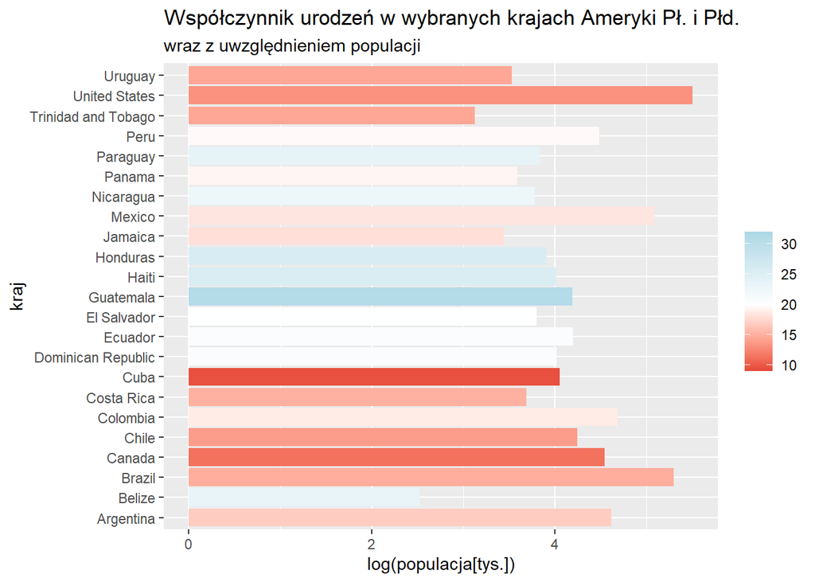

Na powyższym wykresie słupki obrazują populację poszczególnych krajów (a konkretnie logarytm o podstawie z 10 z populacji w tysiącach - taki zabieg miał służyć stworzeniu osi x o niezbyt dużych wartościach). Każdy słupek ma inny kolor w zależności od współczynnika urodzeń. Intuicyjnie słupek państwa z największym współczynnikiem urodzeń powinien być zaznaczony na najciemniejszy kolor spośród użytych, a ten z najmniejszym na jaśniejszy. Na powyższym wykresie jest na odwrót, państwa z najmniejszym wsółczynnikiem urodzenia są zaznaczone na najciemniejszy i najbardziej wyróżniający się kolor, czyli czerwony. Z kolei te pośrednie na biało, a te z największym współczynnikiem na jasnoniebiesko. Taki dobór kolorów miał zmylić ankietowanych przy pozornie prostych pytaniach.

### Statystyki odpowiedzi na pytania 1-2:

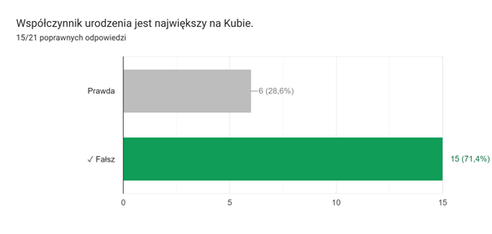

Pytanie 1

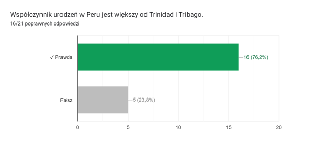

Pytanie 2

## Wykres 2

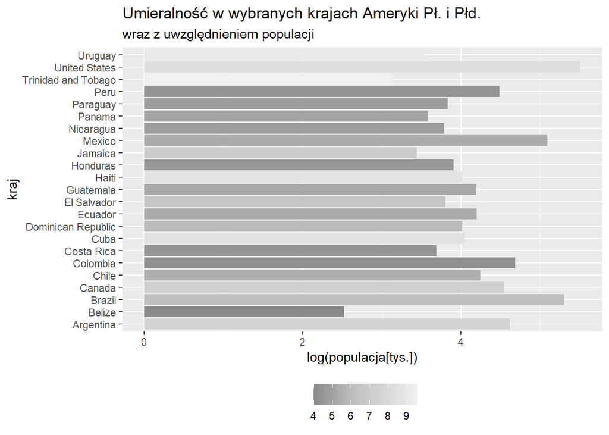

Powyższy wykres jest bardzo podobny do pierwszego pod względem struktury. Tutaj jednak przyglądamy się wielkości współczynnika zgonów, a nie urodzeń. Podobnie jak na poprzednim wykresie skala kolorystyczna jest dobrana na odwrót niż powinna być - słupek kraju z najmniejszym współczynnikiem zgonów jest zaznaczony najciemniejszym kolorem. Tutaj w dodatku jest to podwójnie nieintuicyje, ponieważ podświadomie kojarzymy śmierć z kolorem czarnym, więc tym bardziej ciemny słupek kojarzymy z krajem o największej umieralności. Czytelność wykresu psuje też mała różnica między odcieniami szarości, przez co ciężko jest porównywać umieralność między niektórymi krajami czy w ogóle wskazać kraj z największym współczynnikiem zgonów.

### Statystyki odpowiedzi na pytania 3-4:

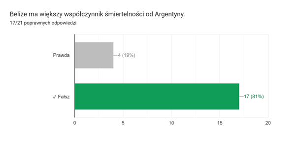

Pytanie 3

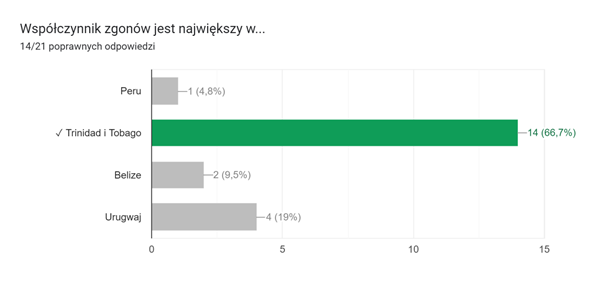

Pytanie 4

## Wykres 3

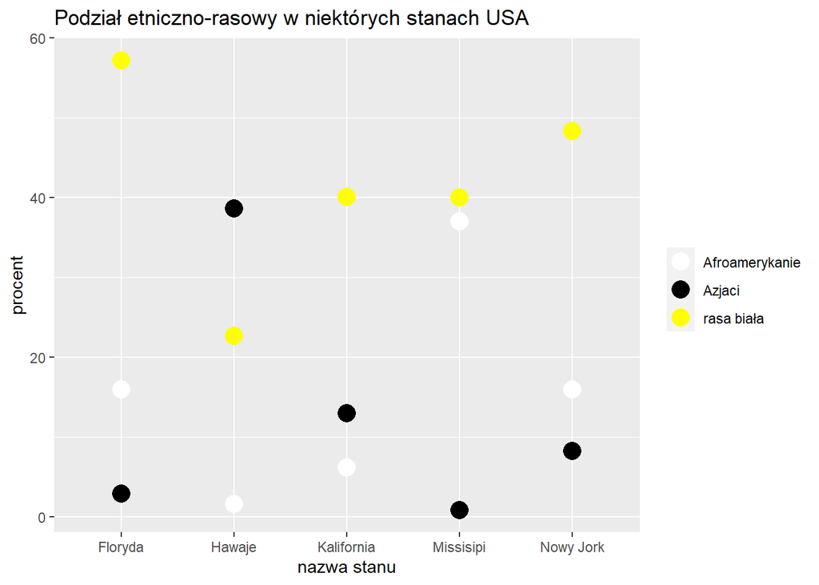

Powyższy wykres punktowy przedstawia podział mieszkańców wybranych stanów USA pod względem etniczno-rasowym. Na pozór wydaje się, że jest to poprawnie zrobiony wykres, jednak zastosowane kolory mogą znacząco zmylić odbiorcę. Na wykresie odczytamy jaki procent ludności stanowią Afroameykanie, rasa biała i Azjaci, użyte kolory na wykresie do zaznaczania tych danych to żółty, czarny i biały. Podświadomie ze względu na kolor skóry kojarzymy żółty kolor z Azjatami itd. Jednak na powyższym wykresie kolory są dopasowane losowo. Aby poprawić czytelność wykresu należałoby dopasować kolory tak jak nam podpowiada intuicja, albo użyć kompletnie innych, niezwiązanych z kolorem skóry np. niebieski, zielony i pomarańczowy.

### Statystyki dotyczące pytań 5-6:

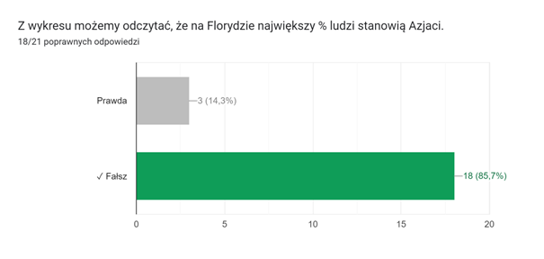

Pytanie 5

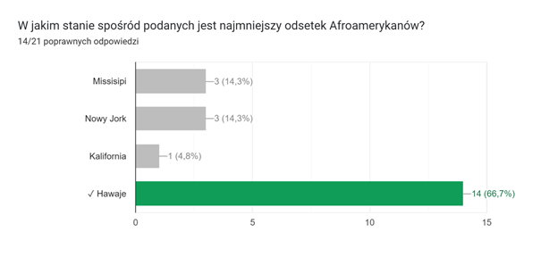

Pytanie 6

### Ogólne statystyki:

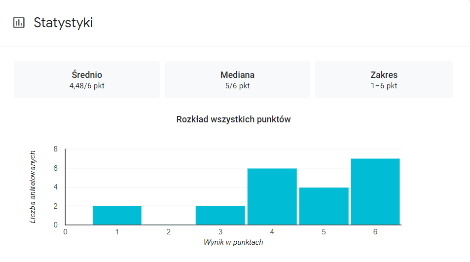

statystyki

Patrząc na wyniki ankiety możemy stwierdzić, że faktycznie niepoprawnie dobrane kolory zmyliły częśc ankietowanych, tylko 1/3 osób odpowiedziała poprawnie na wszystkie pytania, a były 2 osoby (czyli około 10%), które udzieliły tylko jednej poprawnej odpowiedzi przy tak prostych pytaniach. Rozesłaliśmy nowe ankiety do kilku osób z najmniejszą liczbą punktów. Tym razem wykresy były poprawione i prezentowały się tak jak poniżej, a pytania pozostały bez zmian. Tym razem było 100% poprawnych odpowiedzi (przy pierwszej ankiecie wyłączona została opcja wyśwetlenia swojego wyniku i poprawnych ocen).

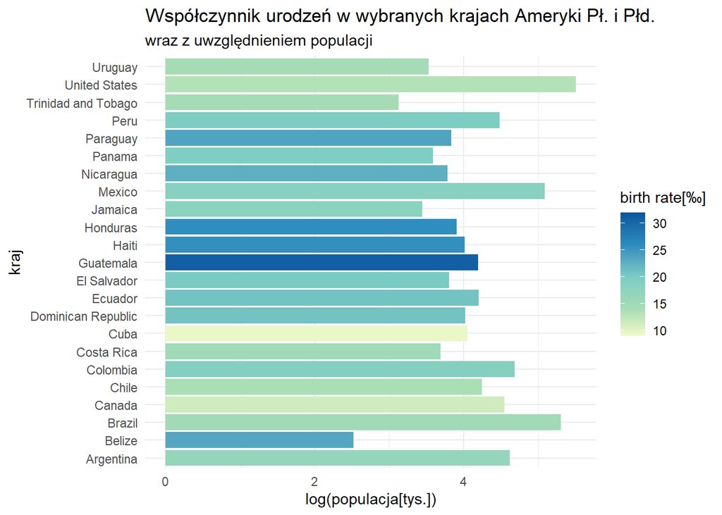

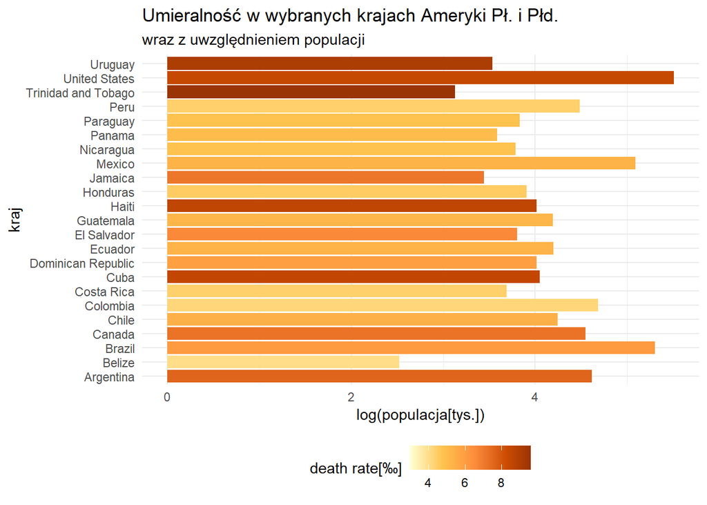

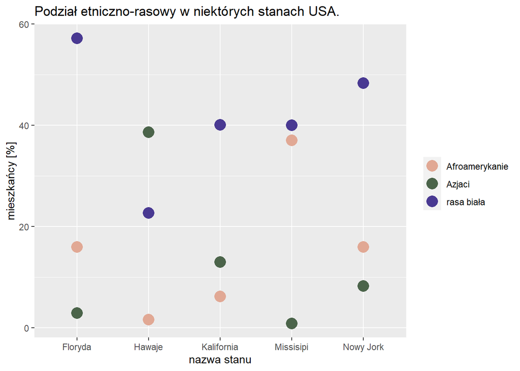

#### Eksperyment jednoznacznie potwierdza, że odpowiedni dobór palety kolorów jest niezbędny do dobrej prezentacji wykresu, tak aby w jasny sposób przedstawić jego treść nawet przy krótkiej uwadze użytkownika.

# Eksperyment II - manipulacja osiami

##### Dane użyte do tego wykresu zostały wymyślone.

## Wykres:

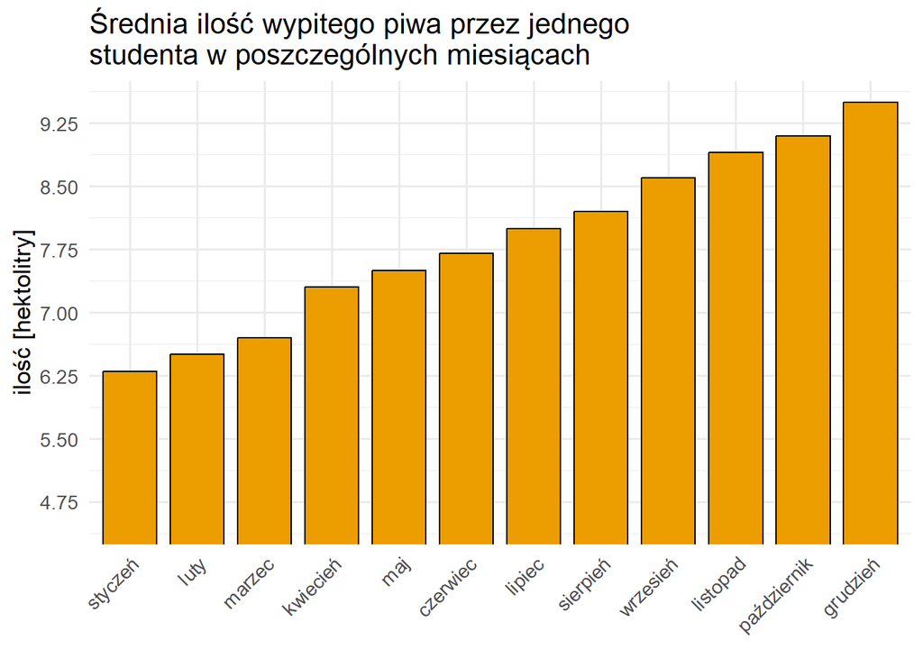

## Pytania i odpowiedzi:

### Pytanie 1

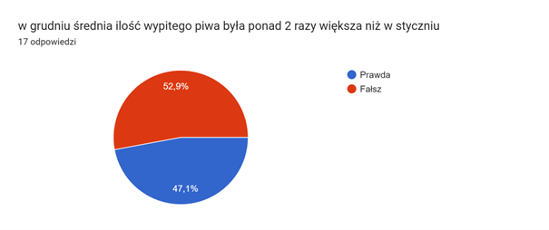

### Pytanie 2

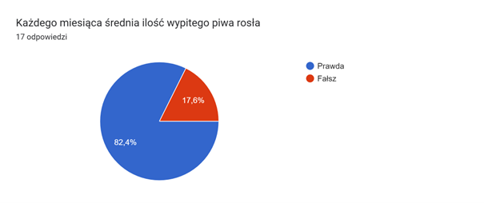

To pytanie okazało się być najtrudniejsze, ponieważ zaledwie 17,6% ankietowanych przypatrzyło się nazwom miesięcy na osi x.

### Pytanie 3

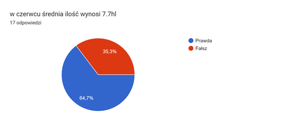

Na ostatnie pytanie zdecydowana większość odpowiedziała poprawnie, jednakże w tym przypadku bez treści pytania, raczej nikt nie byłby w stanie podać dokładnej wartości.

## Wnioski:

##### Patrząc na wyniki tego eksperymentu można zauważyć jak bardzo łatwo jest oszukać odbiorcę manipulując jedynie wartościami na osiach. Jest tak, ponieważ zazwyczaj ludzie nie przyglądają się dokładnie wykresom, zwłaszcza gdy mają na obejrzenie go zaledwie kilka sekund.

# EKSPERYMENT III - wykresy kołowe

Celem doświadczenia było zbadanie, w jaki sposób typ wykresu oraz dobór kolorów wpływa na poprawne odczytanie danych. Pod uwagę wzięto wykres kołowy, kołowy 3D oraz wykres słupkowy, każdy w wersji czarno-białej oraz kolorystycznej. Wykresy przedstawiały te same wartości, modyfikowane było jedynie ich rozmieszczenie.

Test został przeprowadzony za pomocą ankiety google forms. Składa się on z 16 pytań, w których na podstawie danego wykresu należy określić, w której klasie spośród A, B, C, D i E jest najwięcej uczniów, a także ocenić pomoc kolorów w dokonywaniu wyboru oraz wyłonić wykresy najczytelniejsze oraz te, które zmusiły do dłużej obserwacji i zastanowienia. Dane zostały wygenerowane samodzielnie na potrzeby eksperymentu.

## wykres kołowy

Poniższe 5 z 6 wykresów kołowych zostało odczytanych poprawnie przez wszystkich ankietowanych.

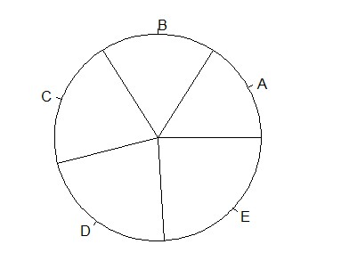

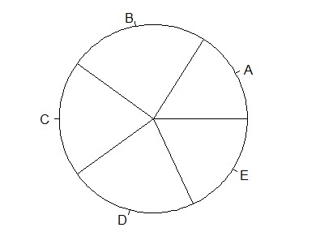

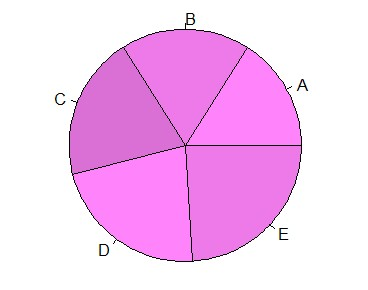

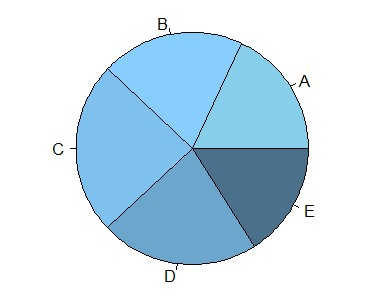

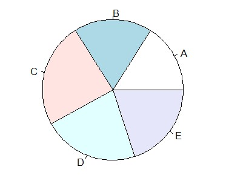

Problem sprawił jedynie jeden z wykresów kolorowych, na którym drugi największy wycinek koła (B) jest w ciemniejszym kolorze niż największy (D), i jako pierwszy rzuca się w oczy. Poprawnej odpowiedzi na to pytanie udzieliło tylko 58,8% osób.

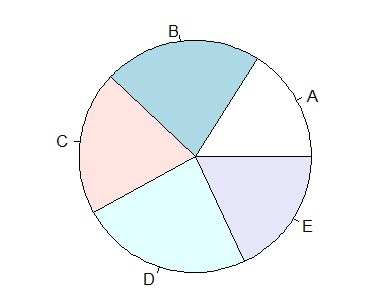

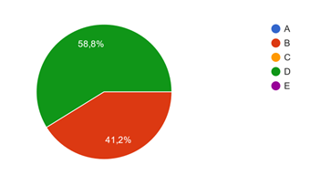

## wykres kołowy 3D

Wykresy kołowe 3D sprawiły dużo więcej problemów. Zdania ankietowanych były bardziej podzielone i większość z nich odpowiadała niepoprawnie, ponieważ kąt, pod którym widzimy wykres, zaburza proporcje między wycinkami. Przykładowo:

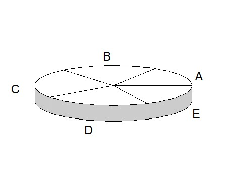

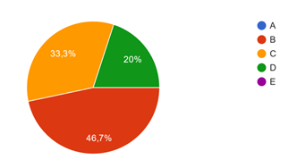

poprawna odpowiedź: C

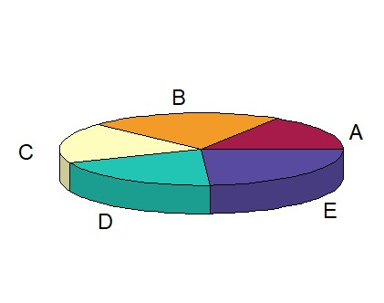

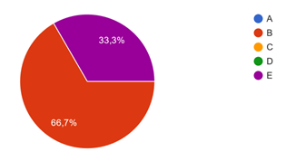

poprawna odpowiedż: E

## wykres słupkowy

W przykładach z wykresami słupkowymi, nie było żadnych błędów. Wszyscy odczytali poniższe wykresy prawidłowo.

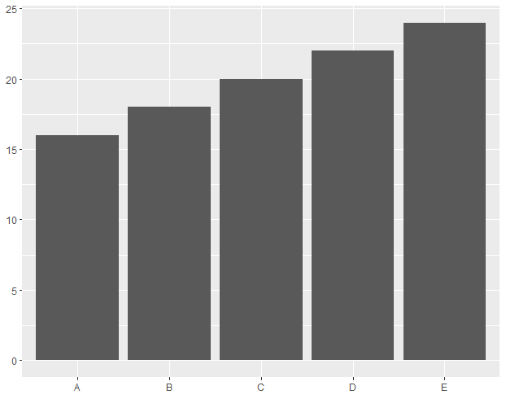

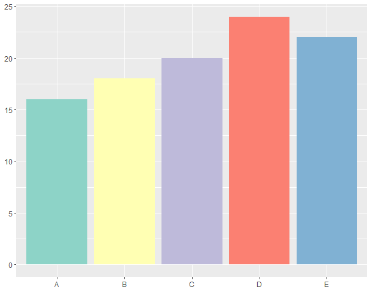

## pytania dodatkowe

- Czy kolory na wykresach kołowych pomogły Ci odpowiedzieć?

  35,3 % TAK 64,7% NIE
- Czy kolory na wykresach słupkowych pomogły Ci odpowiedzieć?

  0 % TAK 100% NIE
- Przy których wykresach musiałeś zastanowić się najdłużej?

Najczęściej wybierane były wykres kołowy 3D bez kolorów (wystąpił w 73,3% przesłanych odpowiedzi) oraz wykres kołowy 3D z kolorami (wystąpił w 53,3 % przesłanych odpowiedzi).

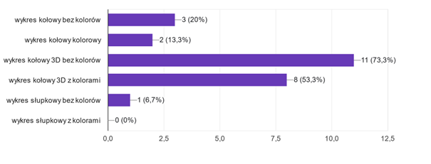

- Które wykresy uważasz za najczytelniejsze?

Najczęściej wybierane były wykres słupkowy bez kolorów (wystąpił w 60 % przesłanych odpowiedzi) oraz wykres słupkowy z kolorami (wystąpił w 53,3 % przesłanych odpowiedzi).

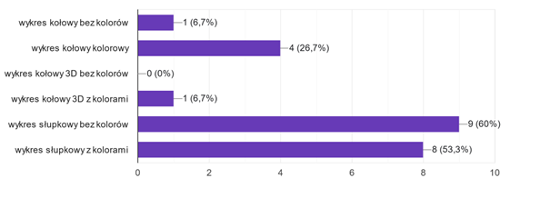

## Wnioski

Badanie potwierdza, że ogólnoprzyjete zasady dobrej wizualizacji danych działają. Zdecydowanie należy unikać, a wręcz po prostu nie korzystać z wykresów kołowych 3D. Bardzo trudno odczytać z nich prawidłowo wyniki i wmaga to więcej czasu niż w innych przykładach. Lepszą opcją będzie wybranie wykresu kołowego 2D, który w konkretnych przypadkach może dobrze się sprawdzić. Trzeba jednak uważać na układ wartości na wykresie oraz dobór kolorów, gdyż pewne kombinacje mogą zmylić optycznie czytelnika. Jeżeli jednak nasze dane nie wymagają, aby koniecznie przedstawiać je na kole, najbezpieczniej jest wybrać wykres słupkowy. Zdaniem uczestników ankiety, dodanie kolorów na takim wykresie nie wpływa na zmniejszenie czytelności wykresu, ale także nie pomaga w odczytaniu wyników, więc rzeczywiście możemy ograniczyć się do jednego koloru.